[figure not shown]

# Project 1

Environmental Analysis and Outcomes

Rachel Carson, Senior Biologist; Yihui Xie, RStudio Scientist

Published Mar 21, 2023

# 1 Summary

Markdown gives you the freedom to add all your content as plain text, without worrying about all the finer details of styling and spacing. Then when you’re ready, R can create a variety of outputs from your content and add all the styling and resources like images and charts to your finished report.

No more copy-pasting new charts into a report every time the data changes. Just click `Knit` and the document will update all the charts for you.

# 2 Markdown basics

Below are the basic building blocks for writing reports in Markdown.

## 2.1 Headings

Headings or section titles are created by putting the `#` hash symbol in front of text. The number of `#` symbols determines the heading level.

```
# Heading level 1
## Heading level 2
...
```

Which will show as:

# Heading level 1

## Heading level 2

## 2.2 Web links

To add a link in your text use:

```
[A link to the MPCA homepage](https://www.pca.state.mn.us/)
```

Which will show as:

> [A link to the MPCA homepage](https://www.pca.state.mn.us/)

## 2.3 Images

To insert an image, add an `!` in front of the link, and put the location of the image inside the (….):

```
![Alt text describing image](link_to_the_image.png)
```

This Markdown will show a speedy **turtle**:

```
![An orange spotted turtle on a paved road.](turtle.jpg)
```

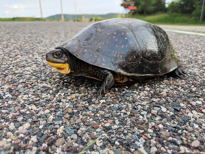

An orange spotted turtle on a paved road.

## 2.4 Size of image

To change the size of an image add `{width = "pct_of_screen%"}` at the end of the line. For example, here is a **smaller** turtle image.

```
![A small orange spotted turtle.](turtle.jpg){width="25%"}
```

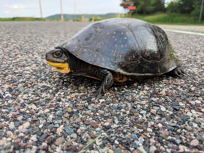

A small orange spotted turtle.

## 2.5 Lists

You can add a bulleted list with dashes:

```markdown
- US CDC
- US EPA
- US Census Bureau
```

> - US CDC
> - US EPA
> - US Census Bureau

## Numbered lists

Create numbered lists by adding `1.` in front of each item. R will take care of updating the 1 to the correct number for each item.

```markdown
1. July 12, 2020
1. July 18, 2020
1. July 23, 2020
```

> 1. July 12, 2020
> 2. July 18, 2020
> 3. July 23, 2020

## 2.6 Call-out boxes

To add call-out boxes for special notes and quotes add the right carrot (`>`) in front of the text. These boxes are also called block quotes.

Markdown:

```markdown
> ### Project details
>
> Who:
> What:
> Where:
```

### Project details

> Who:  
> What:  
> Where:

# 3 R code

To add R scripts to your report, put the code inside a triple backtick sandwich. This is called an an **R chunk**.

> On the keyboard, the `` ` `` (backtick) symbol is on the key up on the far left corner along with the `~` (squiggle line).

### 3.0.1 An R chunk in Markdown

````markdown
```{r}
# R Code Here
library(tidyverse)

my_data <- read_csv("test_results.csv")
```
````

```r
# R Code Here
library(tidyverse)

my_data <- read_csv("test_results.csv")
```

# 4 Chunk options

You can customize the way R code is shown in your report by setting options inside the top `{r}` section of the R chunk.

### 4.0.1 Chunk options

| Chunk option | Description |
| --- | --- |
| `echo = FALSE` | Hides the code, but the code is run and the results and charts are shown. |
| `include = FALSE` | Hides the code and the results, but the code still runs. |
| `eval = FALSE` | Shows the code, but does not evaluate/run it. |
| `message = FALSE` | Hides any messages produced by the code. |
| `warning = FALSE` | Hides any warnings. |
| `fig.alt = "Image alt text"` | The alternative image text read by screen readers. |
| `out.width = "50%"` | Sets the output size for charts made by that chunk. 50% will extend half-way across the screen. |

### 4.0.2 R chunk example

Here’s an R chunk that will show its code in the report (`echo = TRUE`), but the code will not be run (`eval = FALSE`).

````markdown
```{r chunk-name, echo = TRUE, eval = FALSE}
# You will need to install these packages
install.packages("tidyverse")
install.packages("DT")
```
````

# 5 Document options

Settings that apply to your entire document are set in the top YAML section, the bit that starts and ends in `---`.

This is where you can set things like your document’s title, author, and more, like whether to add a table of contents.

### 5.0.1 Document options

| YAML option | Description |
| --- | --- |
| `title:` | Document title |
| `subtitle:` | Document subtitle |
| `author:` | Document author - appears under subtitle |
| `` date: `r format(Sys.Date(), “%b %Y”)` `` | Document date - appears under author |
| `toc-title: "Table of Contents"` | Title for the table of contents |
| `bibliography: bibliography.bib` | File with your references |
| `output: html_document` | Type of document to create from your Markdown |

### 5.0.2 Output types

The following common document types are available (a complete list is [here](https://rmarkdown.rstudio.com/lesson-9.html)):

- [html_document](https://bookdown.org/yihui/rmarkdown/html-document.html)
- [pdf_document](https://bookdown.org/yihui/rmarkdown/pdf-document.html)
- [word_document](https://bookdown.org/yihui/rmarkdown/word-document.html)
- [powerpoint_presentation](https://bookdown.org/yihui/rmarkdown/powerpoint-presentation.html)
- [xaringan::moon_reader](https://bookdown.org/yihui/rmarkdown/xaringan.html) - Creates slide presentations to run in the browser
- [github_document](https://rmarkdown.rstudio.com/github_document_format.html) - Simple Markdown documents for posting to GitLab or GitHub
- [flexdashboard::flex_dashboard](https://rmarkdown.rstudio.com/flexdashboard/) - Interactive dashboards to be viewed in the browser

These options are available to set under the `output:` document option.

| YAML output options | Description |
| --- | --- |
| `toc: true` | Add a table of contents? `true` or `false` |
| `toc_depth: 1` | How many headings deep to show in table of contents? |
| `number_sections: true` | Add numbers in front of your headings (e.g. **2. Second section** )? `true` or `false` |
| `self-contained: true` | Include all an html document’s files/resources internally? `true` or `false` |
| `fig_caption: FALSE` | Stops the Alt text for images being shown as a caption below the image. |